```python
%matplotlib inline
```

```python
import matplotlib.pyplot as plt
plt.style.use('classic')
import seaborn as sns
import numpy as np
import pandas as pd
from mpl_toolkits.mplot3d import Axes3D
import math
from mpl_toolkits import mplot3d

from svn_util.dplot import VectorGround
```

# Linear dependency .Definitions and theorems

#### Linear dependecy

deff : let's to have set of n vectors $\vec{r}_i\in L^n linear space$ if exists real numbers $\gamma_i\in |R $ such that : $$\sum_{i=n}^{n}\gamma_i.r_i=0$$ the vecors $\vec{r}_i$ are linear dependent

### Theorem 1:

##### if the n vectors for example $\vec{r_1}=r_{11}.\vec{e}_1 +r_{12}.\vec{e}_2 + _{13}.\vec{e}_3 $

##### and $\vec{r_2}=r_{21}.\vec{e}_1 +r_{22}.\vec{e}_2 + _{23}.\vec{e}_3 $

, $\vec{r_3}=r_{31}.\vec{e}_1 +r_{32}.\vec{e}_2 + _{33}.\vec{e}_3 $ where $\vec{r}_{i}\in{L^3}$

##### are linear dependent then $\det{R}=0$

$\large\det{R}=\large{\bigtriangleup} \begin{pmatrix} r_{11} & r_{21} & r_{31} \\ r_{12} & r_{22} & r_{32} \\ r_{13} & r_{23} & r_{33} \end{pmatrix} \quad$ $\large {=0}$

#### proof:

if vectors $\vec{r_1}$ and $\vec{r_2}$,$\vec{r_3}$ are linear depend then by deffinition we have $$\gamma_1.\vec{r}_1 + \gamma_2.\vec{r}_2 + \gamma_3.\vec{r}_3 = 0 $$ wich can be expressed as :
$\gamma_1.(r_{11}\vec{e}_1+r_{12}\vec{e}_2+r_{13}\vec{e}_3) $ + $\gamma_2.(r_{21}\vec{e}_1+r_{22}\vec{e}_2+r_{23}\vec{e}_3) $ + $ \gamma_3.(r_{31}\vec{e}_1+r_{32}\vec{e}_2+r_{33}\vec{e}_3) = $
$(\gamma_1.r_{11} + \gamma_2.r_{21} +\gamma_3.r_{31}).\vec{e}_1 $ + $(\gamma_1.r_{12} + \gamma_2.r_{22} +\gamma_3.r_{31}).\vec{e}_2 $ $(\gamma_1.r_{13} + \gamma_2.r_{23} +\gamma_3.r_{33}).\vec{e}_3 = 0 $
the desion are when $$ \gamma_i.r_{ik}=0$$ in matrix form expressed $\large{R*Y=0}$

$\begin{pmatrix} r_{11} & r_{21} & r_{31} \\ r_{12} & r_{22} & r_{32} \\ r_{13} & r_{23} & r_{33} \end{pmatrix}$ * $\begin{pmatrix} \gamma_{11} \\ \gamma_{12} \\ \gamma_{13} \end{pmatrix}$ = $\begin{pmatrix} 0 \\ 0 \\ 0 \end{pmatrix} \quad$

From theory of linear algebra we know that the above matrix eqation has only desion when $\det{R}=0$

and $\det{R}=\det{R^T}$ is true as well

R^T = transpose matrix of R wich is

$\large{R^T}=$ $\begin{pmatrix} r_{11} & r_{21} & r_{31} \\ r_{12} & r_{22} & r_{32} \\ r_{13} & r_{23} & r_{33}\end{pmatrix}\quad$

from above discussion $\Rightarrow$ $\large{det{R^T}=0}$ and threorem is proven

#### Example :

let's to have $r_1=2.\vec{e}_1+3.\vec{e}_2$ and $r_1=4.\vec{e}_1+6.\vec{e}_2$

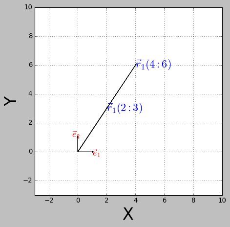

```python
g = VectorGround()
g.add_v(0,0,2,3,font_size=20)
g.add_v(0,0,4,6,font_size=20)
```

#### we can see from geometric graphic that the vector are linear depends

#### but lets to check if exists $\gamma_i$ $\gamma_2$ ,

$\gamma_i.\vec{r}_1 + \gamma_2.\vec{r}_2 =$
$\gamma_1.(2.\vec{e}_1+3.\vec{e}_2) + \gamma_2.(4.\vec{e}_1+6.\vec{e}_2) = $
$ (\gamma_1.2+\gamma_2.4)\vec{e} +(\gamma_1.3+\gamma_2.6)\vec{e}=0 $
$ \Rightarrow$
$(\gamma_1.2+\gamma_2.4) =0 $
$(\gamma_1.3+\gamma_2.6) =0 $ in matrix form :
$$\begin{pmatrix} 2 & 4 \\ 3 & 6 \end{pmatrix}* \begin{pmatrix} \gamma_1 \\ \gamma_2 \end{pmatrix}= \begin{pmatrix} 0 \\ 0 \end{pmatrix} \quad$$

the above eqation has a decision only when $\det{A} = 0$ $$\det{A} = r_{11}.r_{22} -r_{12}.r_{21} = 2*6 - 3*4 =0$$

#### from above theore $ \Rightarrow$ $\gamma_i$ $\gamma_2$ exists and $\gamma_1=-2.\gamma_2$ and moreover we can and from $|\vec{r}_1|=\gamma |\vec{r_2}|$ we can calculate that $\gamma=r_{11}/r_{21}$=1/2

### Threorem 2:

##### if vectors $\vec{r}_1,\vec{r}_2,\vec{r}_3$ satisfy $\vec{r}_1 \perp \vec{r}_3 $ and $\vec{r}_2 \perp \vec{r}_3 $ $\Rightarrow$ $\vec{r}_1$ and $\vec{r}_2$ are linear dependent

#### Proof :

if $\vec{r}_1\perp\vec{r}_3$ then the angle between the both vector $\alpha$=90 and moreover the dot product $<\vec{r}_1|\vec{r}_2>=|\vec{r}_1|.|\vec{r}_2|.\cos{90}=r_{ki}.r_{li}=0$  
in matrix $r_{ki}.r_{li}=0$ in matrix form form we ca write :

$$\begin{pmatrix} r_{11} & r_{12} \end{pmatrix}* \begin{pmatrix} r_{31}\\ r_{32} \end{pmatrix}=0 \quad$$$$\begin{pmatrix} r_{21} & r_{22} \end{pmatrix}* \begin{pmatrix} r_{31}\\r_{32} \end{pmatrix}=0 \quad$$

###### their union

$$\begin{pmatrix} r_{11} & r_{12} \\ r_{21} & r_{22} \end{pmatrix}* \begin{pmatrix} r_{31}\\ r_{32} \end{pmatrix}=0 \quad$$

#### from theorem 1$\Rightarrow$ $\vec{r}_1$ and $\vec{r}_1$ are linear dependent

#### ! when $\vec{r}_1$ , $\vec{r}_2$ ,$\vec{r}_3$ $\in$ $L^2$ then $\vec{r}_1$ , $\vec{r}_2$ lie one same line and when$\vec{r}_1$ , $\vec{r}_2$ ,$\vec{r}_3$ $\in$ $L^3$ then $\vec{r}_1$ , $\vec{r}_2 $ are linear independent then $\vec{r}_1$ , $\vec{r}_2$ form plane with vectors $\vec{z}=a.\vec{r}_1+b.\vec{r}_2 $ wich is pependicular to $\vec{r}_3$ a,b is just a scallar if demension L>3 they can form hyperplane